# 01_differential_expression

Maryam Shojaei Shahrokhabadi

2026-01-07

## 1. Differential expression analysis

The prostate dataset contains expression measurements for 6,033 genes in 102 subjects: 50 healthy controls and 52 prostate cancer patients. The aim of this analysis is to identify genes whose expression differs between the two groups.

Because a separate test is performed for each of the 6,033 genes, the main statistical challenge is multiple testing: at a significance level of 0.05, around 300 genes would be expected to appear significant by chance alone, even if no gene were truly differentially expressed. Multiplicity corrections are therefore required to control the number of false discoveries.

Two approaches are compared. The first is a classical gene-by-gene test, the Wilcoxon rank-sum test, which analyses each gene independently. The second is limma, which also fits a separate model for each gene but uses empirical Bayes moderation to borrow information across genes, giving more stable variance estimates when sample sizes are small.

### 1.1 Data exploration

The expression matrix contained no missing values and no zero values, so no imputation or filtering was required before analysis.

To check whether the assumptions of parametric tests were reasonable, expression values were compared between the two groups. Figure 1 shows the distribution of expression values across the different groups. The cancer groups display greater variability than the control group, with a wider spread of expression values and several outlying observations. Unequal variances and outliers violate the assumptions of the classical two-sample t-test, which motivates the use of a more robust approach.

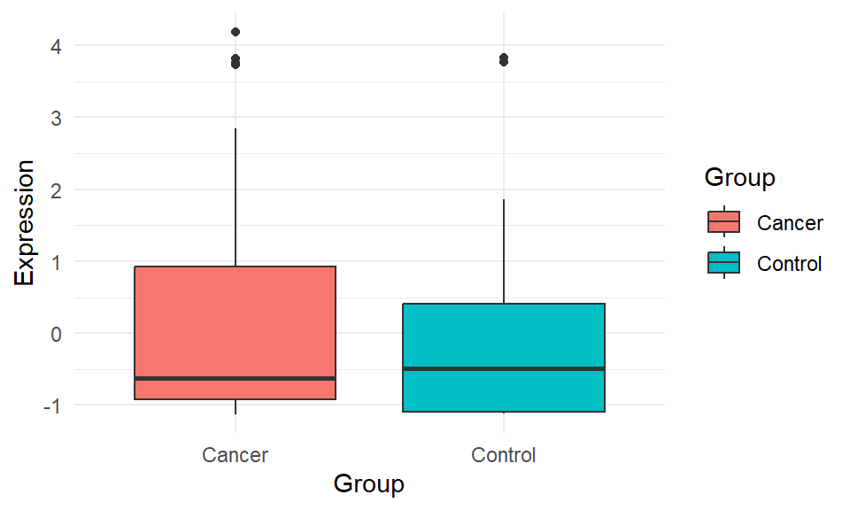

**Figure 1.Distribution of gene expression values across study groups. Boxplots show the median, interquartile range, and overall distribution of expression values within each group. The cancer groups show greater variability and several potential outlying observations compared with the control group.**

The four genes with the highest variability were examined to assess the distribution of their expression values across the study groups. The expression distributions were right-skewed and showed departures from normality (Figure 2). Given these distributional characteristics, a non-parametric Wilcoxon rank-sum test was used to compare expression levels between the groups for each gene.

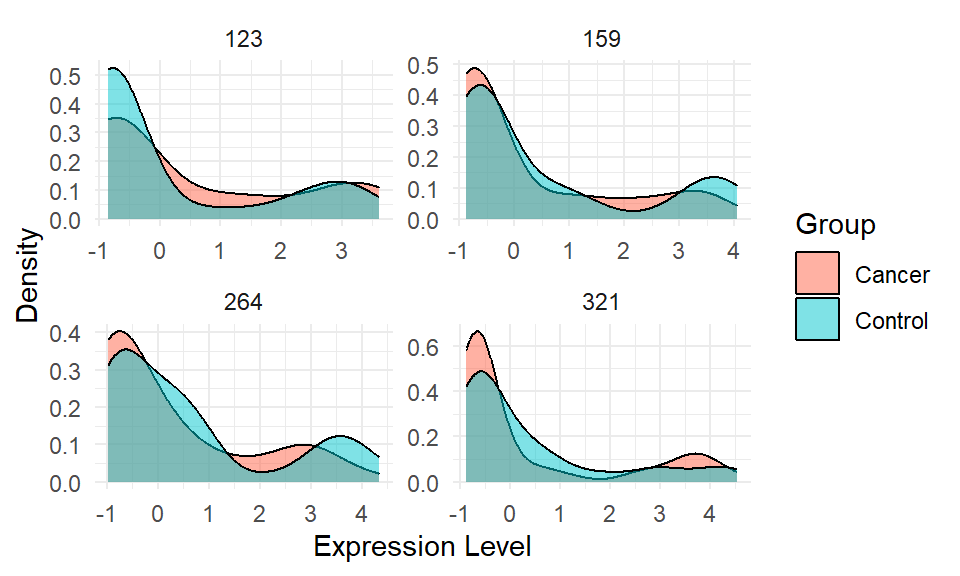

**Figure 2. Density of expression for the four most variable genes, by group.**

### 1.2 Wilcoxon Rank-Sum test

#### 1.2.1 Wilcoxon test hypothesis for gene expression

For each gene, the Wilcoxon test evaluates whether expression values in one group tend to be larger than in the other. Let $X_{cancer}$ and $X_{control}$ denote the expression of a randomly chosen cancer and control subject. The hypotheses are:

**Null hypothesis ($H_0$):** Cancer and control groups have similar expression distributions.

$$H_0:\; P(X_C > X_H) = 0.5$$

**Alternative hypothesis ($H_1$):** Cancer and control groups have different expression distributions.

$$P(X_C > X_H) \neq 0.5$$

#### 1.2.2 Results of the Wilcoxon test

Figure 3 shows the distribution of the raw p-values from the 6,033 tests. If no gene were differentially expressed, the p-values would follow a uniform distribution and the histogram would be flat. Instead, there is a clear peak near zero on top of an approximately flat background. This pattern indicates that most genes are not differentially expressed, but a subset shows a real difference between cancer and control subjects.

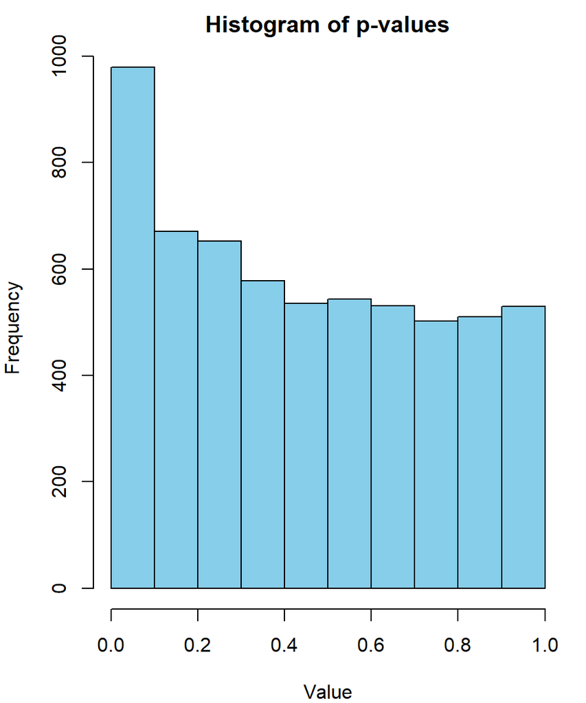

**Figure 3. Histogram of raw p-values from the Wilcoxon test for all 6,033 genes.**

Table 1 compares the number of significant genes under different multiple testing corrections. Without correction, 615 genes are significant at the 5% level, but many of these are expected to be false positives. Methods that control the family-wise error rate (Bonferroni and Holm) are very strict and retain only 9 genes. The Benjamini–Hochberg procedure, which instead controls the false discovery rate, identifies 61 genes.

**Table 1. Number of genes declared significant at different significance levels, by correction method.**

|  |  | Bonferroni | Holm | BH | BY |
| --- | --- | --- | --- | --- | --- |
| 0 | 0 | 0 | 0 | 0 | 0 |
| 0.05 | 615 | 9 | 9 | 61 | 5 |
| 0.1 | 979 | 10 | 10 | 110 | 10 |
| 0.15 | 1333 | 12 | 12 | 156 | 13 |
| 0.2 | 1650 | 12 | 12 | 193 | 19 |
| 0.25 | 1970 | 14 | 14 | 230 | 21 |
| 0.3 | 2302 | 15 | 15 | 267 | 38 |
| 0.35 | 2583 | 16 | 16 | 336 | 50 |
| 0.4 | 2880 | 19 | 19 | 414 | 59 |
| 0.45 | 3138 | 19 | 19 | 524 | 60 |
| 0.5 | 3416 | 20 | 20 | 649 | 64 |

Figure 4 combines statistical significance with the magnitude of the observed changes in a volcano plot. Each point represents a gene, with the x-axis showing the log₂ fold change between the cancer and control groups and the y-axis representing the statistical significance of the result. Genes highlighted in red are significant after Benjamini–Hochberg (BH) correction. The dashed line indicates the BH significance threshold, while the dotted blue line represents the more stringent Holm threshold. The figure shows that substantially fewer genes meet the Holm-adjusted significance threshold.

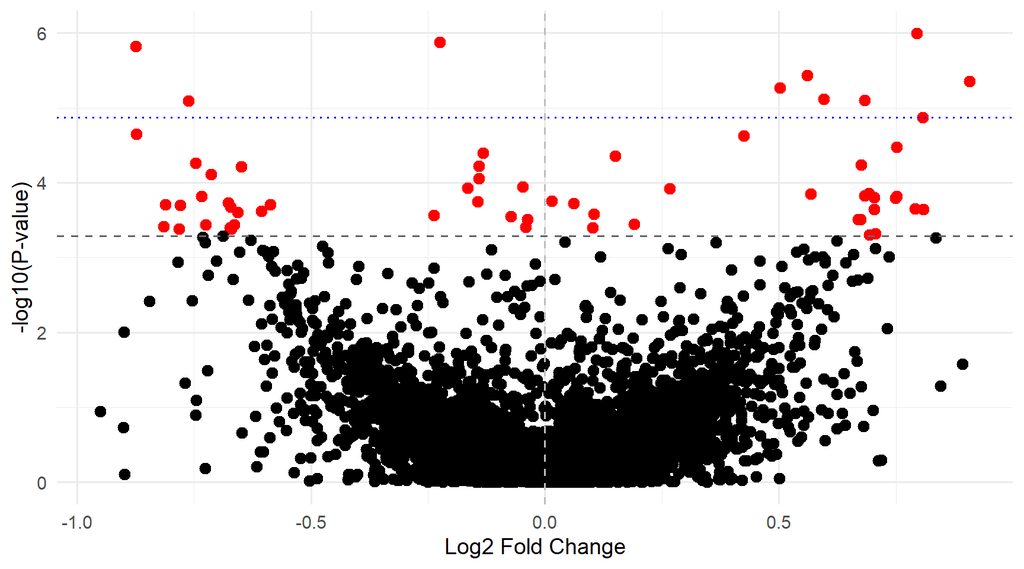

**Figure 4. Volcano plot of the Wilcoxon test results. Red points are genes significant after BH correction.**

Statistical significance alone does not necessarily indicate that a difference is biologically meaningful, as very small expression differences can become statistically significant with sufficiently large sample sizes. Therefore, Figure 5 applies an additional fold-change threshold of |log₂FC| > 0.75 to identify genes with relatively larger expression differences between the groups. The significance thresholds identify genes with statistically significant changes, while the fold-change cutoff provides an additional measure of the magnitude of these changes. Genes meeting both criteria were considered differentially expressed in this analysis.

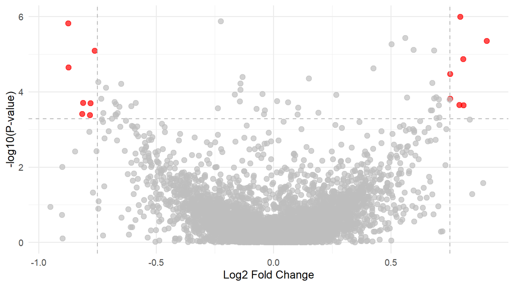

**Figure 5. Volcano plot with BH significance threshold and fold-change cutoffs (|log₂FC| > 0.75). Red points meet both criteria.**

### 1.3 Differential expression with limma

### 1.3.1 Model and hypothesis

As a second approach, a linear model was fitted to each gene using the limma package. For gene $j$ and subject $i$, expression is modelled as:

$$X_{ij} = \beta_{0j} + \beta_{1j} Group_i
+ \epsilon_{ij}$$

where: $\beta_{0j}$: The gene-specific intercept (the mean expression of gene $j$ in the control group).

$\beta_{1j}$: log2 fold change between cancer and control (the difference in mean expression between cancer and control).

$Group$: The indicator variable representing the disease status (equals 1 for cancer subjects and 0 for controls).

$\epsilon_{ij}$: Random error term.

The statistical hypotheses:
$$H_0: \beta_{1j} = 0$$
$$H_1: \beta_{1j} \neq 0$$

This model on its own is equivalent to a two-sample t-test for each gene. The key difference in limma is how the variance is estimated. With only around 50 subjects per group, gene-specific variance estimates are noisy: some genes appear significant only because their variance happens to be underestimated. limma uses empirical Bayes moderated t-statistics, which borrow information across genes to stabilise variance estimates in small samples.

### 1.3.12 Limma results

The limma analysis identified 26 differentially expressed genes after Benjamini–Hochberg correction, compared with 61 genes identified using the Wilcoxon test. Figure 6 shows the limma volcano plot. Compared with the Wilcoxon volcano plot, the points form a more pronounced V-shaped pattern. This reflects the use of moderated variance estimates in limma, which stabilise the variance estimates across genes by borrowing information across the dataset. As a result, genes with larger fold changes generally show stronger statistical evidence, although the significance of each gene also depends on the estimated variance and sample size.

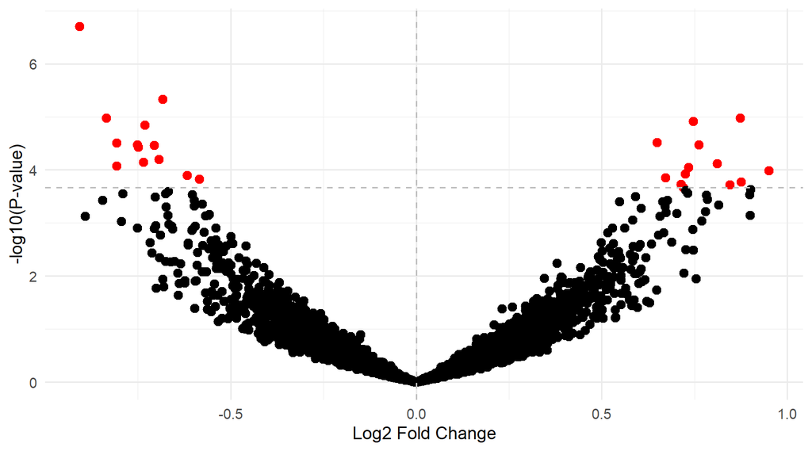

**Figure 6. Volcano plot of the limma results. Red points are genes significant after BH correction; the dashed line marks the BH threshold.**

### 1.4 Comparison of the two methods

To assess the consistency of the differential expression results, the findings from the limma and Wilcoxon methods were compared. Both methods were used to identify genes that differed in expression between the cancer and control groups, but they rely on different statistical approaches. Comparing their results helps identify genes that are consistently detected across methods and may therefore be less dependent on the choice of statistical test.

- limma identified 26 significant genes (BH-adjusted) and the Wilcoxon test identified 61; 18 genes were found by both methods.
- Of the 18 shared genes, 8 also had |log₂FC| > 0.75: genes 739, 610, 4331, 3647, 3940, 579, 3991 and 3375. These are the most robust candidates.

### 1.5 Conclusion

Both approaches found evidence of differential expression between prostate cancer patients and controls, but they differed in how many genes they identified. The Wilcoxon test detected more genes, consistent with the skewed and outlier-prone distributions in the data. 8 genes were significant under both methods and showed large fold changes, making them the most robust candidates for further biological investigation.